# Project: Wrangling and Analyze Data

## Data Gathering

> 1. Directly download the WeRateDogs Twitter archive data (twitter_archive_enhanced.csv)

```python
import pandas as pd

df_twitter = pd.read_csv('twitter-archive-enhanced.csv')

df_twitter
```

|  | tweet_id | in_reply_to_status_id | in_reply_to_user_id | timestamp | source | text | retweeted_status_id | retweeted_status_user_id | retweeted_status_timestamp | expanded_urls | rating_numerator | rating_denominator | name | doggo | floofer | pupper | puppo |
| --- | --- | --- | --- | --- | --- | --- | --- | --- | --- | --- | --- | --- | --- | --- | --- | --- | --- |
| 0 | 892420643555336193 | NaN | NaN | 2017-08-01 16:23:56 +0000 | <a href="http://twitter.com/download/iphone" r... | This is Phineas. He's a mystical boy. Only eve... | NaN | NaN | NaN | https://twitter.com/dog_rates/status/892420643... | 13 | 10 | Phineas | None | None | None | None |
| 1 | 892177421306343426 | NaN | NaN | 2017-08-01 00:17:27 +0000 | <a href="http://twitter.com/download/iphone" r... | This is Tilly. She's just checking pup on you.... | NaN | NaN | NaN | https://twitter.com/dog_rates/status/892177421... | 13 | 10 | Tilly | None | None | None | None |
| 2 | 891815181378084864 | NaN | NaN | 2017-07-31 00:18:03 +0000 | <a href="http://twitter.com/download/iphone" r... | This is Archie. He is a rare Norwegian Pouncin... | NaN | NaN | NaN | https://twitter.com/dog_rates/status/891815181... | 12 | 10 | Archie | None | None | None | None |
| 3 | 891689557279858688 | NaN | NaN | 2017-07-30 15:58:51 +0000 | <a href="http://twitter.com/download/iphone" r... | This is Darla. She commenced a snooze mid meal... | NaN | NaN | NaN | https://twitter.com/dog_rates/status/891689557... | 13 | 10 | Darla | None | None | None | None |
| 4 | 891327558926688256 | NaN | NaN | 2017-07-29 16:00:24 +0000 | <a href="http://twitter.com/download/iphone" r... | This is Franklin. He would like you to stop ca... | NaN | NaN | NaN | https://twitter.com/dog_rates/status/891327558... | 12 | 10 | Franklin | None | None | None | None |
| ... | ... | ... | ... | ... | ... | ... | ... | ... | ... | ... | ... | ... | ... | ... | ... | ... | ... |
| 2351 | 666049248165822465 | NaN | NaN | 2015-11-16 00:24:50 +0000 | <a href="http://twitter.com/download/iphone" r... | Here we have a 1949 1st generation vulpix. Enj... | NaN | NaN | NaN | https://twitter.com/dog_rates/status/666049248... | 5 | 10 | None | None | None | None | None |
| 2352 | 666044226329800704 | NaN | NaN | 2015-11-16 00:04:52 +0000 | <a href="http://twitter.com/download/iphone" r... | This is a purebred Piers Morgan. Loves to Netf... | NaN | NaN | NaN | https://twitter.com/dog_rates/status/666044226... | 6 | 10 | a | None | None | None | None |
| 2353 | 666033412701032449 | NaN | NaN | 2015-11-15 23:21:54 +0000 | <a href="http://twitter.com/download/iphone" r... | Here is a very happy pup. Big fan of well-main... | NaN | NaN | NaN | https://twitter.com/dog_rates/status/666033412... | 9 | 10 | a | None | None | None | None |
| 2354 | 666029285002620928 | NaN | NaN | 2015-11-15 23:05:30 +0000 | <a href="http://twitter.com/download/iphone" r... | This is a western brown Mitsubishi terrier. Up... | NaN | NaN | NaN | https://twitter.com/dog_rates/status/666029285... | 7 | 10 | a | None | None | None | None |
| 2355 | 666020888022790149 | NaN | NaN | 2015-11-15 22:32:08 +0000 | <a href="http://twitter.com/download/iphone" r... | Here we have a Japanese Irish Setter. Lost eye... | NaN | NaN | NaN | https://twitter.com/dog_rates/status/666020888... | 8 | 10 | None | None | None | None | None |

2356 rows × 17 columns

> 1. Use the Requests library to download the tweet image prediction (image_predictions.tsv) from the given url

```python
import requests

url = 'https://d17h27t6h515a5.cloudfront.net/topher/2017/August/599fd2ad_image-predictions/image-predictions.tsv'

#download the file and save it as "image_predictions.tsv" in the current working directory.
response = requests.get(url)

with open('image_predictions.tsv', 'wb') as file:
    file.write(response.content)


df_image = pd.read_csv('image_predictions.tsv',sep = '\t')

df_image
```

|  | tweet_id | jpg_url | img_num | p1 | p1_conf | p1_dog | p2 | p2_conf | p2_dog | p3 | p3_conf | p3_dog |
| --- | --- | --- | --- | --- | --- | --- | --- | --- | --- | --- | --- | --- |
| 0 | 666020888022790149 | https://pbs.twimg.com/media/CT4udn0WwAA0aMy.jpg | 1 | Welsh_springer_spaniel | 0.465074 | True | collie | 0.156665 | True | Shetland_sheepdog | 0.061428 | True |
| 1 | 666029285002620928 | https://pbs.twimg.com/media/CT42GRgUYAA5iDo.jpg | 1 | redbone | 0.506826 | True | miniature_pinscher | 0.074192 | True | Rhodesian_ridgeback | 0.072010 | True |
| 2 | 666033412701032449 | https://pbs.twimg.com/media/CT4521TWwAEvMyu.jpg | 1 | German_shepherd | 0.596461 | True | malinois | 0.138584 | True | bloodhound | 0.116197 | True |
| 3 | 666044226329800704 | https://pbs.twimg.com/media/CT5Dr8HUEAA-lEu.jpg | 1 | Rhodesian_ridgeback | 0.408143 | True | redbone | 0.360687 | True | miniature_pinscher | 0.222752 | True |
| 4 | 666049248165822465 | https://pbs.twimg.com/media/CT5IQmsXIAAKY4A.jpg | 1 | miniature_pinscher | 0.560311 | True | Rottweiler | 0.243682 | True | Doberman | 0.154629 | True |
| ... | ... | ... | ... | ... | ... | ... | ... | ... | ... | ... | ... | ... |
| 2070 | 891327558926688256 | https://pbs.twimg.com/media/DF6hr6BUMAAzZgT.jpg | 2 | basset | 0.555712 | True | English_springer | 0.225770 | True | German_short-haired_pointer | 0.175219 | True |
| 2071 | 891689557279858688 | https://pbs.twimg.com/media/DF_q7IAWsAEuuN8.jpg | 1 | paper_towel | 0.170278 | False | Labrador_retriever | 0.168086 | True | spatula | 0.040836 | False |
| 2072 | 891815181378084864 | https://pbs.twimg.com/media/DGBdLU1WsAANxJ9.jpg | 1 | Chihuahua | 0.716012 | True | malamute | 0.078253 | True | kelpie | 0.031379 | True |
| 2073 | 892177421306343426 | https://pbs.twimg.com/media/DGGmoV4XsAAUL6n.jpg | 1 | Chihuahua | 0.323581 | True | Pekinese | 0.090647 | True | papillon | 0.068957 | True |
| 2074 | 892420643555336193 | https://pbs.twimg.com/media/DGKD1-bXoAAIAUK.jpg | 1 | orange | 0.097049 | False | bagel | 0.085851 | False | banana | 0.076110 | False |

2075 rows × 12 columns

> 1. Use the Tweepy library to query additional data via the Twitter API (tweet_json.txt)

```python
import tweepy
from tweepy import OAuthHandler
import json
from timeit import default_timer as timer

# Query Twitter API for each tweet in the Twitter archive and save JSON in a text file
# These are hidden to comply with Twitter's API terms and conditions
consumer_key = 'HIDDEN'
consumer_secret = 'HIDDEN'
access_token = 'HIDDEN'
access_secret = 'HIDDEN'

auth = OAuthHandler(consumer_key, consumer_secret)
auth.set_access_token(access_token, access_secret)

api = tweepy.API(auth, wait_on_rate_limit=True)

tweet_ids = df_twitter.tweet_id.values
len(tweet_ids)

# Query Twitter's API for JSON data for each tweet ID in the Twitter archive
count = 0
fails_dict = {}
start = timer()
# Save each tweet's returned JSON as a new line in a .txt file
with open('tweet_json.txt', 'w') as outfile:
    # This loop will likely take 20-30 minutes to run because of Twitter's rate limit
    for tweet_id in tweet_ids:
        count += 1
        print(str(count) + ": " + str(tweet_id))
        try:
            tweet = api.get_status(tweet_id, tweet_mode='extended')
            print("Success")
            json.dump(tweet._json, outfile)
            outfile.write('\n')
        except tweepy.errors.TweepError as e:
            print("Fail")
            fails_dict[tweet_id] = e
            pass
end = timer()
print(end - start)
print(fails_dict)
```

```python
import json
with open('tweet-json.txt') as file:
    status = []
    for line in file:
        status.append(json.loads(line))
status = pd.DataFrame.from_records(status)

df_2 = pd.read_json('tweet-json.txt',lines=True)

df_json = df_2[["id","favorite_count","retweet_count"]]


df_json
```

|  | id | favorite_count | retweet_count |
| --- | --- | --- | --- |
| 0 | 892420643555336193 | 39467 | 8853 |
| 1 | 892177421306343426 | 33819 | 6514 |
| 2 | 891815181378084864 | 25461 | 4328 |
| 3 | 891689557279858688 | 42908 | 8964 |
| 4 | 891327558926688256 | 41048 | 9774 |
| ... | ... | ... | ... |
| 2349 | 666049248165822465 | 111 | 41 |
| 2350 | 666044226329800704 | 311 | 147 |
| 2351 | 666033412701032449 | 128 | 47 |
| 2352 | 666029285002620928 | 132 | 48 |
| 2353 | 666020888022790149 | 2535 | 532 |

2354 rows × 3 columns

## Assessing Data

> **df_twitter**

```python
list(df_twitter)
```

```
['tweet_id',
 'in_reply_to_status_id',
 'in_reply_to_user_id',
 'timestamp',
 'source',
 'text',
 'retweeted_status_id',
 'retweeted_status_user_id',
 'retweeted_status_timestamp',
 'expanded_urls',
 'rating_numerator',
 'rating_denominator',
 'name',
 'doggo',
 'floofer',
 'pupper',
 'puppo']
```

```python
df_twitter.info()
```

```
<class 'pandas.core.frame.DataFrame'>
RangeIndex: 2356 entries, 0 to 2355
Data columns (total 17 columns):
 #   Column                      Non-Null Count  Dtype
---  ------                      --------------  -----
 0   tweet_id                    2356 non-null   int64
 1   in_reply_to_status_id       78 non-null     float64
 2   in_reply_to_user_id         78 non-null     float64
 3   timestamp                   2356 non-null   object
 4   source                      2356 non-null   object
 5   text                        2356 non-null   object
 6   retweeted_status_id         181 non-null    float64
 7   retweeted_status_user_id    181 non-null    float64
 8   retweeted_status_timestamp  181 non-null    object
 9   expanded_urls               2297 non-null   object
 10  rating_numerator            2356 non-null   int64
 11  rating_denominator          2356 non-null   int64
 12  name                        2356 non-null   object
 13  doggo                       2356 non-null   object
 14  floofer                     2356 non-null   object
 15  pupper                      2356 non-null   object
 16  puppo                       2356 non-null   object
dtypes: float64(4), int64(3), object(10)
memory usage: 313.0+ KB
```

```python
df_twitter.describe()
```

|  | tweet_id | in_reply_to_status_id | in_reply_to_user_id | retweeted_status_id | retweeted_status_user_id | rating_numerator | rating_denominator |
| --- | --- | --- | --- | --- | --- | --- | --- |
| count | 2.356000e+03 | 7.800000e+01 | 7.800000e+01 | 1.810000e+02 | 1.810000e+02 | 2356.000000 | 2356.000000 |
| mean | 7.427716e+17 | 7.455079e+17 | 2.014171e+16 | 7.720400e+17 | 1.241698e+16 | 13.126486 | 10.455433 |
| std | 6.856705e+16 | 7.582492e+16 | 1.252797e+17 | 6.236928e+16 | 9.599254e+16 | 45.876648 | 6.745237 |
| min | 6.660209e+17 | 6.658147e+17 | 1.185634e+07 | 6.661041e+17 | 7.832140e+05 | 0.000000 | 0.000000 |
| 25% | 6.783989e+17 | 6.757419e+17 | 3.086374e+08 | 7.186315e+17 | 4.196984e+09 | 10.000000 | 10.000000 |
| 50% | 7.196279e+17 | 7.038708e+17 | 4.196984e+09 | 7.804657e+17 | 4.196984e+09 | 11.000000 | 10.000000 |
| 75% | 7.993373e+17 | 8.257804e+17 | 4.196984e+09 | 8.203146e+17 | 4.196984e+09 | 12.000000 | 10.000000 |
| max | 8.924206e+17 | 8.862664e+17 | 8.405479e+17 | 8.874740e+17 | 7.874618e+17 | 1776.000000 | 170.000000 |

```python
df_twitter['name'].value_counts()
```

```
None          745
a              55
Charlie        12
Cooper         11
Lucy           11
             ...
Dex             1
Ace             1
Tayzie          1
Grizzie         1
Christoper      1
Name: name, Length: 957, dtype: int64
```

```python
df_twitter['doggo'].value_counts()
```

```
None     2259
doggo      97
Name: doggo, dtype: int64
```

```python
df_twitter['floofer'].value_counts()
```

```
None       2346
floofer      10
Name: floofer, dtype: int64
```

```python
df_twitter['pupper'].value_counts()
```

```
None      2099
pupper     257
Name: pupper, dtype: int64
```

```python
df_twitter['puppo'].value_counts()
```

```
None     2326
puppo      30
Name: puppo, dtype: int64
```

```python
df_twitter.name.duplicated().sum()
```

```
1399
```

```python
list(df_twitter.rating_numerator)
```

```
[13,
 13,
 12,
 13,
 12,
 13,
 13,
 13,
 13,
 14,
 13,
 13,
 13,
 12,
 13,
 13,
 12,
 13,
 13,
 13,
 12,
 13,
 14,
 13,
 13,
 12,
 13,
 13,
 13,
 12,
 12,
 13,
 12,
 12,
 13,
 14,
 13,
 13,
 12,
 13,
```

[output cut: 946 more lines]

```
 11,
 8,
 10,
 13,
 13,
 11,
 10,
 6,
 12,
 10,
 13,
 11,
 7,
 13,
 ...]
```

```python
list(df_twitter.rating_denominator)
```

[output not shown]

[output cut: 946 more lines]

[output not shown]

> **df_image**

```python
df_image.info()
```

```
<class 'pandas.core.frame.DataFrame'>
RangeIndex: 2075 entries, 0 to 2074
Data columns (total 12 columns):
 #   Column    Non-Null Count  Dtype
---  ------    --------------  -----
 0   tweet_id  2075 non-null   int64
 1   jpg_url   2075 non-null   object
 2   img_num   2075 non-null   int64
 3   p1        2075 non-null   object
 4   p1_conf   2075 non-null   float64
 5   p1_dog    2075 non-null   bool
 6   p2        2075 non-null   object
 7   p2_conf   2075 non-null   float64
 8   p2_dog    2075 non-null   bool
 9   p3        2075 non-null   object
 10  p3_conf   2075 non-null   float64
 11  p3_dog    2075 non-null   bool
dtypes: bool(3), float64(3), int64(2), object(4)
memory usage: 152.1+ KB
```

```python
df_image['img_num'].value_counts()
```

```
1    1780
2     198
3      66
4      31
Name: img_num, dtype: int64
```

> **df_json**

```python
df_json.describe()
```

|  | id | favorite_count | retweet_count |
| --- | --- | --- | --- |
| count | 2.354000e+03 | 2354.000000 | 2354.000000 |
| mean | 7.426978e+17 | 8080.968564 | 3164.797366 |
| std | 6.852812e+16 | 11814.771334 | 5284.770364 |
| min | 6.660209e+17 | 0.000000 | 0.000000 |
| 25% | 6.783975e+17 | 1415.000000 | 624.500000 |
| 50% | 7.194596e+17 | 3603.500000 | 1473.500000 |
| 75% | 7.993058e+17 | 10122.250000 | 3652.000000 |
| max | 8.924206e+17 | 132810.000000 | 79515.000000 |

```python
df_json.info()
```

```
<class 'pandas.core.frame.DataFrame'>
RangeIndex: 2354 entries, 0 to 2353
Data columns (total 3 columns):
 #   Column          Non-Null Count  Dtype
---  ------          --------------  -----
 0   id              2354 non-null   int64
 1   favorite_count  2354 non-null   int64
 2   retweet_count   2354 non-null   int64
dtypes: int64(3)
memory usage: 55.3 KB
```

```python
df_json.favorite_count.value_counts()
```

```
0       179
2706      3
2918      3
610       3
2768      3
       ...
7493      1
6671      1
4484      1
2872      1
2535      1
Name: favorite_count, Length: 2007, dtype: int64
```

```python
df_json.retweet_count.value_counts()
```

```
1972    5
3652    5
83      5
1207    4
336     4
       ..
3357    1
3018    1
2181    1
848     1
147     1
Name: retweet_count, Length: 1724, dtype: int64
```

```python
df_json.id.duplicated().value_counts()
```

```
False    2354
Name: id, dtype: int64
```

```python
df_json.retweet_count.duplicated().sum()
```

```
630
```

```python
df_json.favorite_count.duplicated().sum()
```

```
347
```

```python
df_json.isnull().sum()
```

```
id                0
favorite_count    0
retweet_count     0
dtype: int64
```

### Tidiness issues:

> 1. Timestamp: columns in Twitter_archive_enhanced should be split into Date column and Time column
> 2. The four columns in Twitter_archive_enhanced doggo,floofe,pupper and puppo should be variables in dog_states column
> 3. img_num column in Image_predictions should be writted in full,Image_num.
> 4. the three datasets should be merged together

### Quality issus:

> 1. +0000 should be removed from timestamp column.
> 2. Date and Time values should be split
> 3. name: letter "a" instead of missing name,None in name column.
> 4. some missing values recorded as None instead of NaN
> 5. The name column has dublicate names,charlie,cooper,lucy
> 6. Twitter ratings should be in one column in fraction
> 7. duplicated values in favorite and retweet counts in **tweet_json**
> 8. rating_numerator column contains 1,5,420,666,6,182,960,0,75,7,84,9,24,8,3,4,165,1776 which should be removed
> 9. rating_denominator contains values which are not 10

## Cleaning Data

```python
# Making copies of original pieces of data

twitter_clean = df_twitter.copy()

image_clean = df_image.copy()

json_clean = df_json.copy()
```

#### 1. Removing all +0000 from timestamp column

##### Code

```python
#using the strftime() function to remove the +0000 offset from a datetime column
import pandas as pd

# first convert the column to datetime
twitter_clean['timestamp'] = pd.to_datetime(twitter_clean['timestamp'])

# Remove the offset using strftime
twitter_clean['timestamp'] = twitter_clean['timestamp'].dt.strftime('%Y-%m-%d %H:%M:%S')
```

##### Test

```python
# The offset +0000 will be removed
twitter_clean.sample(5)
```

|  | tweet_id | in_reply_to_status_id | in_reply_to_user_id | timestamp | source | text | retweeted_status_id | retweeted_status_user_id | retweeted_status_timestamp | expanded_urls | rating_numerator | rating_denominator | name | doggo | floofer | pupper | puppo |
| --- | --- | --- | --- | --- | --- | --- | --- | --- | --- | --- | --- | --- | --- | --- | --- | --- | --- |
| 2227 | 668268907921326080 | NaN | NaN | 2015-11-22 03:24:58 | <a href="http://twitter.com/download/iphone" r... | Here we have an Azerbaijani Buttermilk named G... | NaN | NaN | NaN | https://twitter.com/dog_rates/status/668268907... | 10 | 10 | None | None | None | None | None |
| 307 | 835685285446955009 | NaN | NaN | 2017-02-26 02:57:52 | <a href="http://twitter.com/download/iphone" r... | RT @dog_rates: This is Rory. He's got an inter... | 7.869631e+17 | 4.196984e+09 | 2016-10-14 16:13:10 +0000 | https://twitter.com/dog_rates/status/786963064... | 12 | 10 | Rory | None | None | None | None |
| 2065 | 671151324042559489 | NaN | NaN | 2015-11-30 02:18:39 | <a href="http://twitter.com/download/iphone" r... | *struggling to breathe properly* 12/10 https:/... | NaN | NaN | NaN | https://twitter.com/dog_rates/status/671151324... | 12 | 10 | None | None | None | None | None |
| 396 | 825147591692263424 | NaN | NaN | 2017-01-28 01:04:51 | <a href="http://twitter.com/download/iphone" r... | This is Sweet Pea. She hides in shoe boxes and... | NaN | NaN | NaN | https://twitter.com/dog_rates/status/825147591... | 13 | 10 | Sweet | None | None | None | None |
| 774 | 776218204058357768 | NaN | NaN | 2016-09-15 00:36:55 | <a href="http://twitter.com/download/iphone" r... | Atlas rolled around in some chalk and now he's... | NaN | NaN | NaN | https://twitter.com/dog_rates/status/776218204... | 13 | 10 | None | None | floofer | None | None |

#### 2. Creating date and time columns from the timestamp column splitting the values

##### Code

```python
# first converting the column to datetime
twitter_clean['timestamp'] = pd.to_datetime(twitter_clean['timestamp'])

# Creating new columns for date and time using .dt
twitter_clean['date'] = twitter_clean['timestamp'].dt.date
twitter_clean['time'] = twitter_clean['timestamp'].dt.time

# Reordering the columns
cols = twitter_clean.columns.tolist()
cols = cols[:1] + cols[-2:] + cols[1:-2]
twitter_clean = twitter_clean[cols]
```

##### Test

```python
# The dataframe will now have 3 columns: datetime_column, date, and time
twitter_clean.head()
```

|  | tweet_id | date | time | in_reply_to_status_id | in_reply_to_user_id | timestamp | source | text | retweeted_status_id | retweeted_status_user_id | retweeted_status_timestamp | expanded_urls | rating_numerator | rating_denominator | name | doggo | floofer | pupper | puppo |
| --- | --- | --- | --- | --- | --- | --- | --- | --- | --- | --- | --- | --- | --- | --- | --- | --- | --- | --- | --- |
| 0 | 892420643555336193 | 2017-08-01 | 16:23:56 | NaN | NaN | 2017-08-01 16:23:56 | <a href="http://twitter.com/download/iphone" r... | This is Phineas. He's a mystical boy. Only eve... | NaN | NaN | NaN | https://twitter.com/dog_rates/status/892420643... | 13 | 10 | Phineas | None | None | None | None |
| 1 | 892177421306343426 | 2017-08-01 | 00:17:27 | NaN | NaN | 2017-08-01 00:17:27 | <a href="http://twitter.com/download/iphone" r... | This is Tilly. She's just checking pup on you.... | NaN | NaN | NaN | https://twitter.com/dog_rates/status/892177421... | 13 | 10 | Tilly | None | None | None | None |
| 2 | 891815181378084864 | 2017-07-31 | 00:18:03 | NaN | NaN | 2017-07-31 00:18:03 | <a href="http://twitter.com/download/iphone" r... | This is Archie. He is a rare Norwegian Pouncin... | NaN | NaN | NaN | https://twitter.com/dog_rates/status/891815181... | 12 | 10 | Archie | None | None | None | None |
| 3 | 891689557279858688 | 2017-07-30 | 15:58:51 | NaN | NaN | 2017-07-30 15:58:51 | <a href="http://twitter.com/download/iphone" r... | This is Darla. She commenced a snooze mid meal... | NaN | NaN | NaN | https://twitter.com/dog_rates/status/891689557... | 13 | 10 | Darla | None | None | None | None |
| 4 | 891327558926688256 | 2017-07-29 | 16:00:24 | NaN | NaN | 2017-07-29 16:00:24 | <a href="http://twitter.com/download/iphone" r... | This is Franklin. He would like you to stop ca... | NaN | NaN | NaN | https://twitter.com/dog_rates/status/891327558... | 12 | 10 | Franklin | None | None | None | None |

#### 3. replace "a" with None in name column

##### Code

```python
twitter_clean.name = twitter_clean.name.replace('a', np.NaN)
```

##### Tesst

```python
twitter_clean.name.value_counts()
```

```
None          745
Charlie        12
Cooper         11
Lucy           11
Oliver         11
             ...
Aqua            1
Chase           1
Meatball        1
Rorie           1
Christoper      1
Name: name, Length: 956, dtype: int64
```

#### 4. Replace 1,5,420,666,6,182,960,0,75,7,84,9,24,8,3,4,165,1776 values in rating numerator column with random variable.

##### Code

```python
import pandas as pd
import numpy as np

# Replace values 7, 6, and 98 with random values between 10 and 15
twitter_clean['rating_numerator'] = twitter_clean['rating_numerator'].replace([26,27,44,45,50,60,80,88,99,1,5,420,144,666,6,182,143,960,0,75,7,84,9,24,8,3,4,165,1776,121], np.random.randint(10, 15, size=30))
```

##### Test

```python
twitter_clean.rating_numerator.sort_values()
```

```
2079      2
1764      2
1761      2
2246      2
2349      2
       ...
285      15
291      15
55       17
1663     20
1120    204
Name: rating_numerator, Length: 2356, dtype: int64
```

#### 5. replace all values which are not 10 with to in the rating_denominator column

##### Code

```python
# Using where() function method to change all values that are not equal to 10 to 10.

twitter_clean['rating_denominator'] = twitter_clean['rating_denominator'].where(twitter_clean['rating_denominator'] == 10, other=10)
```

##### Test

```python
# using all() function to check if all the values in a column are equal to 10
if (twitter_clean['rating_denominator'] == 10).all():
    print('All values are 10')
else:
    print('Not all values are 10')
```

```
All values are 10
```

##### Code

```python
image_clean.rename(columns = {'img_num': 'image_number'}, inplace = True)
```

##### Test

```python
image_clean.head(2)
```

|  | tweet_id | jpg_url | image_number | p1 | p1_conf | p1_dog | p2 | p2_conf | p2_dog | p3 | p3_conf | p3_dog |
| --- | --- | --- | --- | --- | --- | --- | --- | --- | --- | --- | --- | --- |
| 0 | 666020888022790149 | https://pbs.twimg.com/media/CT4udn0WwAA0aMy.jpg | 1 | Welsh_springer_spaniel | 0.465074 | True | collie | 0.156665 | True | Shetland_sheepdog | 0.061428 | True |
| 1 | 666029285002620928 | https://pbs.twimg.com/media/CT42GRgUYAA5iDo.jpg | 1 | redbone | 0.506826 | True | miniature_pinscher | 0.074192 | True | Rhodesian_ridgeback | 0.072010 | True |

#### 7. Making the column headers; doggo,floofe,pupper and puppo as variables in dog_stages column

##### Code

```python
twitter_clean = twitter_clean.melt(id_vars=[col for col in twitter_clean.columns if col not in twitter_clean.columns[-4:]], value_vars=('doggo','floofer','pupper','puppo'), value_name='dog_stage')
```

##### Test

```python
twitter_clean.dog_stage.value_counts()
```

```
None       9030
pupper      257
doggo        97
puppo        30
floofer      10
Name: dog_stage, dtype: int64
```

#### 8. Remove retweets.

##### Code

```python
# select only rows that have null values in retweet

twitter_clean = twitter_clean[twitter_clean.retweeted_status_id.isnull()]
twitter_clean = twitter_clean[twitter_clean.retweeted_status_user_id.isnull()]
twitter_clean = twitter_clean[twitter_clean.retweeted_status_timestamp.isnull()]
```

##### Test

```python
twitter_clean.sample(4)
```

|  | tweet_id | date | time | in_reply_to_status_id | in_reply_to_user_id | timestamp | source | text | retweeted_status_id | retweeted_status_user_id | retweeted_status_timestamp | expanded_urls | rating_numerator | rating_denominator | name | variable | dog_stage |
| --- | --- | --- | --- | --- | --- | --- | --- | --- | --- | --- | --- | --- | --- | --- | --- | --- | --- |
| 6111 | 699691744225525762 | 2016-02-16 | 20:28:06 | NaN | NaN | 2016-02-16 20:28:06 | <a href="http://twitter.com/download/iphone" r... | This is Dave. He's a tropical pup. Short lil l... | NaN | NaN | NaN | https://twitter.com/dog_rates/status/699691744... | 11 | 10 | Dave | pupper | None |
| 3638 | 708738143638450176 | 2016-03-12 | 19:35:15 | NaN | NaN | 2016-03-12 19:35:15 | <a href="http://twitter.com/download/iphone" r... | This is Coco. She gets to stay on the Bachelor... | NaN | NaN | NaN | https://twitter.com/dog_rates/status/708738143... | 11 | 10 | Coco | floofer | None |
| 8944 | 675111688094527488 | 2015-12-11 | 00:35:44 | NaN | NaN | 2015-12-11 00:35:44 | <a href="http://twitter.com/download/iphone" r... | Say hello to Oliver. He thought what was insid... | NaN | NaN | NaN | https://twitter.com/dog_rates/status/675111688... | 11 | 10 | Oliver | puppo | None |
| 7380 | 835264098648616962 | 2017-02-24 | 23:04:14 | NaN | NaN | 2017-02-24 23:04:14 | <a href="http://twitter.com/download/iphone" r... | Meet Lola. Her hobbies include being precious ... | NaN | NaN | NaN | https://www.gofundme.com/lolas-life-saving-sur... | 12 | 10 | Lola | puppo | None |

#### 8.drop variable,timestamp,retweeted_status_timestamp,retweeted_status_id,in_reply_to_user_id and in_reply_to_user_id columns

##### Code

```python
# dropping variable,timestamp,retweeted_status_timestamp,retweeted_status_id,in_reply_to_user_id and in_reply_to_user_id columns

twitter_clean.drop(columns={'variable', 'timestamp','in_reply_to_user_id','in_reply_to_user_id','retweeted_status_id','retweeted_status_timestamp'},inplace=True)
```

##### Test

```python
twitter_clean.sample(3)
```

|  | tweet_id | date | time | in_reply_to_status_id | source | text | retweeted_status_user_id | expanded_urls | rating_numerator | rating_denominator | name | dog_stage |
| --- | --- | --- | --- | --- | --- | --- | --- | --- | --- | --- | --- | --- |
| 8652 | 687096057537363968 | 2016-01-13 | 02:17:20 | NaN | <a href="http://twitter.com/download/iphone" r... | This pupper's New Year's resolution was to bec... | NaN | https://twitter.com/dog_rates/status/687096057... | 11 | 10 | None | None |
| 4320 | 673350198937153538 | 2015-12-06 | 03:56:12 | NaN | <a href="http://twitter.com/download/iphone" r... | This is Bella. She's a Genghis Flopped Canuck.... | NaN | https://twitter.com/dog_rates/status/673350198... | 10 | 10 | Bella | None |
| 3106 | 779123168116150273 | 2016-09-23 | 01:00:13 | NaN | <a href="http://twitter.com/download/iphone" r... | This is Reggie. He hugs everyone he meets. 12/... | NaN | https://twitter.com/dog_rates/status/779123168... | 12 | 10 | Reggie | None |

#### 9. Drop duplicate rows in the dataset

##### Code

```python
# dropping the duplicated files using tweet_id as reference

twitter_clean.drop_duplicates(subset=['tweet_id'],inplace=True)
```

##### Test

```python
#lets now confirm any duplicates


twitter_clean.tweet_id.duplicated().value_counts()
```

```
False    2175
Name: tweet_id, dtype: int64
```

#### 10. replace none values with NaN in the name column

##### Code

```python
twitter_clean['name'] = twitter_clean['name'].replace(to_replace='None', value=np.nan).dropna()
```

##### Test

```python
list(twitter_clean.name)
```

```
['Phineas',
 'Tilly',
 'Archie',
 'Darla',
 'Franklin',
 nan,
 'Jax',
 nan,
 'Zoey',
 'Cassie',
 'Koda',
 'Bruno',
 nan,
 'Ted',
 'Stuart',
 'Oliver',
 'Jim',
 'Zeke',
 'Ralphus',
 'Gerald',
 'Jeffrey',
 'such',
 'Canela',
 nan,
 nan,
 'Maya',
 'Mingus',
 'Derek',
 'Roscoe',
 nan,
 'Waffles',
 'Jimbo',
 'Maisey',
 nan,
 nan,
 'Earl',
 'Lola',
 'Kevin',
 nan,
 nan,
```

[output cut: 946 more lines]

```
 'Jangle',
 nan,
 'Schnitzel',
 'Panda',
 'Oliver',
 'Archie',
 'Berkeley',
 nan,
 'Ralphé',
 'Derek',
 'Charleson',
 'Neptune',
 nan,
 'Clyde',
 ...]
```

#### Renamed *id* column to tweet_id on json_clean

##### Code

```python
json_clean.rename(columns = {'id':'tweet_id'}, inplace=True)
```

##### Test

```python
json_clean.head(3)
```

|  | tweet_id | favorite_count | retweet_count |
| --- | --- | --- | --- |
| 0 | 892420643555336193 | 39467 | 8853 |
| 1 | 892177421306343426 | 33819 | 6514 |
| 2 | 891815181378084864 | 25461 | 4328 |

#### 12. Remove lower case words in the name column

##### Code

```python
twitter_clean.dropna(subset=['name'], how='all', inplace=True)

twitter_clean = twitter_clean[twitter_clean['name'].str[0].str.isupper()]
```

```python
twitter_clean = twitter_clean[twitter_clean['name'].str[0].str.isupper()]
```

##### Test

```python
twitter_clean
```

|  | tweet_id | date | time | in_reply_to_status_id | source | text | retweeted_status_user_id | expanded_urls | rating_numerator | rating_denominator | name | dog_stage |
| --- | --- | --- | --- | --- | --- | --- | --- | --- | --- | --- | --- | --- |
| 0 | 892420643555336193 | 2017-08-01 | 16:23:56 | NaN | <a href="http://twitter.com/download/iphone" r... | This is Phineas. He's a mystical boy. Only eve... | NaN | https://twitter.com/dog_rates/status/892420643... | 13 | 10 | Phineas | None |
| 1 | 892177421306343426 | 2017-08-01 | 00:17:27 | NaN | <a href="http://twitter.com/download/iphone" r... | This is Tilly. She's just checking pup on you.... | NaN | https://twitter.com/dog_rates/status/892177421... | 13 | 10 | Tilly | None |
| 2 | 891815181378084864 | 2017-07-31 | 00:18:03 | NaN | <a href="http://twitter.com/download/iphone" r... | This is Archie. He is a rare Norwegian Pouncin... | NaN | https://twitter.com/dog_rates/status/891815181... | 12 | 10 | Archie | None |
| 3 | 891689557279858688 | 2017-07-30 | 15:58:51 | NaN | <a href="http://twitter.com/download/iphone" r... | This is Darla. She commenced a snooze mid meal... | NaN | https://twitter.com/dog_rates/status/891689557... | 13 | 10 | Darla | None |
| 4 | 891327558926688256 | 2017-07-29 | 16:00:24 | NaN | <a href="http://twitter.com/download/iphone" r... | This is Franklin. He would like you to stop ca... | NaN | https://twitter.com/dog_rates/status/891327558... | 12 | 10 | Franklin | None |
| ... | ... | ... | ... | ... | ... | ... | ... | ... | ... | ... | ... | ... |
| 2315 | 666691418707132416 | 2015-11-17 | 18:56:35 | NaN | <a href="http://twitter.com/download/iphone" r... | This is Christoper. He is a spotted Penne. Can... | NaN | https://twitter.com/dog_rates/status/666691418... | 11 | 10 | Christoper | None |
| 2317 | 666644823164719104 | 2015-11-17 | 15:51:26 | NaN | <a href="http://twitter.com/download/iphone" r... | This is Jimothy. He is a Botwanian Gouda. Can ... | NaN | https://twitter.com/dog_rates/status/666644823... | 10 | 10 | Jimothy | None |
| 2318 | 666454714377183233 | 2015-11-17 | 03:16:00 | NaN | <a href="http://twitter.com/download/iphone" r... | I'll name the dogs from now on. This is Kreggo... | NaN | https://twitter.com/dog_rates/status/666454714... | 10 | 10 | Kreggory | None |
| 2319 | 666447344410484738 | 2015-11-17 | 02:46:43 | NaN | <a href="http://twitter.com/download/iphone" r... | This is Scout. She is a black Downton Abbey. I... | NaN | https://twitter.com/dog_rates/status/666447344... | 10 | 10 | Scout | None |
| 2325 | 666418789513326592 | 2015-11-17 | 00:53:15 | NaN | <a href="http://twitter.com/download/iphone" r... | This is Walter. He is an Alaskan Terrapin. Lov... | NaN | https://twitter.com/dog_rates/status/666418789... | 10 | 10 | Walter | None |

1391 rows × 12 columns

```python
list(twitter_clean.name)
```

```
['Phineas',
 'Tilly',
 'Archie',
 'Darla',
 'Franklin',
 'Jax',
 'Zoey',
 'Cassie',
 'Koda',
 'Bruno',
 'Ted',
 'Stuart',
 'Oliver',
 'Jim',
 'Zeke',
 'Ralphus',
 'Gerald',
 'Jeffrey',
 'Canela',
 'Maya',
 'Mingus',
 'Derek',
 'Roscoe',
 'Waffles',
 'Jimbo',
 'Maisey',
 'Earl',
 'Lola',
 'Kevin',
 'Yogi',
 'Noah',
 'Bella',
 'Grizzwald',
 'Rusty',
 'Gus',
 'Stanley',
 'Alfy',
 'Koko',
 'Rey',
 'Gary',
```

[output cut: 946 more lines]

```
 'Jerry',
 'Oreo',
 'Bruiser',
 'Perry',
 'Theodore',
 'Bobby',
 'Pippa',
 'Jeph',
 'Obi',
 'Tino',
 'Kulet',
 'Sweets',
 'Lupe',
 'Sadie',
 ...]
```

#### 13. merge the three datasets

##### Code

```python
twitter_merged = twitter_clean.merge(image_clean,on='tweet_id').merge(json_clean,on='tweet_id')
```

##### Test

```python
twitter_merged
```

|  | tweet_id | date | time | in_reply_to_status_id | source | text | retweeted_status_user_id | expanded_urls | rating_numerator | rating_denominator | ... | p1_conf | p1_dog | p2 | p2_conf | p2_dog | p3 | p3_conf | p3_dog | favorite_count | retweet_count |
| --- | --- | --- | --- | --- | --- | --- | --- | --- | --- | --- | --- | --- | --- | --- | --- | --- | --- | --- | --- | --- | --- |
| 0 | 892420643555336193 | 2017-08-01 | 16:23:56 | NaN | <a href="http://twitter.com/download/iphone" r... | This is Phineas. He's a mystical boy. Only eve... | NaN | https://twitter.com/dog_rates/status/892420643... | 13 | 10 | ... | 0.097049 | False | bagel | 0.085851 | False | banana | 0.076110 | False | 39467 | 8853 |
| 1 | 892177421306343426 | 2017-08-01 | 00:17:27 | NaN | <a href="http://twitter.com/download/iphone" r... | This is Tilly. She's just checking pup on you.... | NaN | https://twitter.com/dog_rates/status/892177421... | 13 | 10 | ... | 0.323581 | True | Pekinese | 0.090647 | True | papillon | 0.068957 | True | 33819 | 6514 |
| 2 | 891815181378084864 | 2017-07-31 | 00:18:03 | NaN | <a href="http://twitter.com/download/iphone" r... | This is Archie. He is a rare Norwegian Pouncin... | NaN | https://twitter.com/dog_rates/status/891815181... | 12 | 10 | ... | 0.716012 | True | malamute | 0.078253 | True | kelpie | 0.031379 | True | 25461 | 4328 |
| 3 | 891689557279858688 | 2017-07-30 | 15:58:51 | NaN | <a href="http://twitter.com/download/iphone" r... | This is Darla. She commenced a snooze mid meal... | NaN | https://twitter.com/dog_rates/status/891689557... | 13 | 10 | ... | 0.170278 | False | Labrador_retriever | 0.168086 | True | spatula | 0.040836 | False | 42908 | 8964 |
| 4 | 891327558926688256 | 2017-07-29 | 16:00:24 | NaN | <a href="http://twitter.com/download/iphone" r... | This is Franklin. He would like you to stop ca... | NaN | https://twitter.com/dog_rates/status/891327558... | 12 | 10 | ... | 0.555712 | True | English_springer | 0.225770 | True | German_short-haired_pointer | 0.175219 | True | 41048 | 9774 |
| ... | ... | ... | ... | ... | ... | ... | ... | ... | ... | ... | ... | ... | ... | ... | ... | ... | ... | ... | ... | ... | ... |
| 1345 | 666691418707132416 | 2015-11-17 | 18:56:35 | NaN | <a href="http://twitter.com/download/iphone" r... | This is Christoper. He is a spotted Penne. Can... | NaN | https://twitter.com/dog_rates/status/666691418... | 11 | 10 | ... | 0.975401 | True | beagle | 0.008687 | True | bloodhound | 0.005394 | True | 196 | 51 |
| 1346 | 666644823164719104 | 2015-11-17 | 15:51:26 | NaN | <a href="http://twitter.com/download/iphone" r... | This is Jimothy. He is a Botwanian Gouda. Can ... | NaN | https://twitter.com/dog_rates/status/666644823... | 10 | 10 | ... | 0.044333 | True | Pembroke | 0.043209 | True | West_Highland_white_terrier | 0.038906 | True | 238 | 88 |
| 1347 | 666454714377183233 | 2015-11-17 | 03:16:00 | NaN | <a href="http://twitter.com/download/iphone" r... | I'll name the dogs from now on. This is Kreggo... | NaN | https://twitter.com/dog_rates/status/666454714... | 10 | 10 | ... | 0.278954 | True | Labrador_retriever | 0.237612 | True | Great_Pyrenees | 0.171106 | True | 545 | 223 |
| 1348 | 666447344410484738 | 2015-11-17 | 02:46:43 | NaN | <a href="http://twitter.com/download/iphone" r... | This is Scout. She is a black Downton Abbey. I... | NaN | https://twitter.com/dog_rates/status/666447344... | 10 | 10 | ... | 0.322084 | True | giant_schnauzer | 0.287955 | True | Labrador_retriever | 0.166331 | True | 107 | 23 |
| 1349 | 666418789513326592 | 2015-11-17 | 00:53:15 | NaN | <a href="http://twitter.com/download/iphone" r... | This is Walter. He is an Alaskan Terrapin. Lov... | NaN | https://twitter.com/dog_rates/status/666418789... | 10 | 10 | ... | 0.149680 | True | papillon | 0.148258 | True | Chihuahua | 0.142860 | True | 129 | 48 |

1350 rows × 25 columns

#### 14. Replace None values in dog_stage with NaN

##### Code

```python
twitter_merged['dog_stage'] = twitter_merged['dog_stage'].replace(to_replace='None', value=np.nan).dropna()
```

##### Test

```python
list(twitter_merged.dog_stage)
```

[output not shown]

[output cut: 946 more lines]

[output not shown]

## Storing Data

```python
twitter_merged.to_csv('twitter_archive_master.csv', index = False)
```

```python
df = pd.read_csv('twitter_archive_master.csv')

df.dog_stage.value_counts()
```

```
doggo    40
Name: dog_stage, dtype: int64
```

## Analyzing and Visualizing Data

```python
import pandas as pd
import matplotlib.pyplot as plt
%matplotlib inline

#Function to generate a scatter plot of two columns in the gun_census dataset.


def scatter_plots(data, x_col, y_col):
    #This function takes in a pandas DataFrame, a column name for the x-axis, and a column name for the y-axis.It returns scatter plots for each unique value in the x-axis column.
    unique_values = data[x_col].unique()
    for value in unique_values:
        value_data = data[data[x_col] == value]
        plt.scatter(value_data[x_col], value_data[y_col])



    plt.xlabel(x_col)
    plt.ylabel(y_col)
    plt.title('Plot of ' + x_col + 'VS' + y_col)
    plt.show()

    plt.savefig('plot1.png')
```

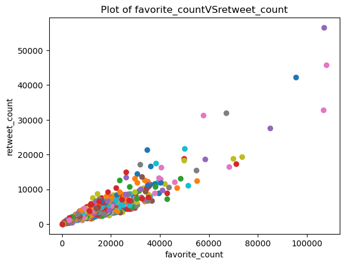

```python
scatter_plots(df, "favorite_count", "retweet_count");
```

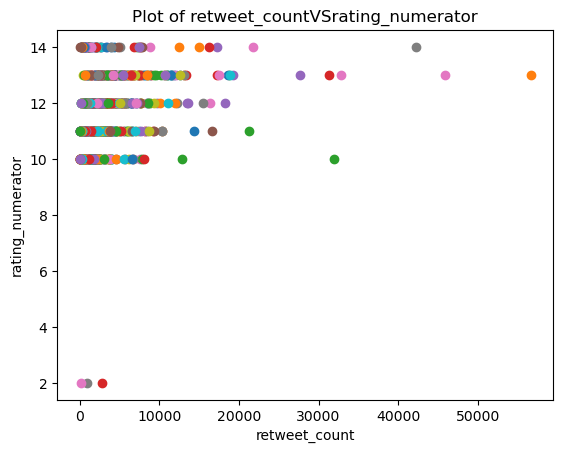

```python
scatter_plots(df, "retweet_count", "rating_numerator");
```

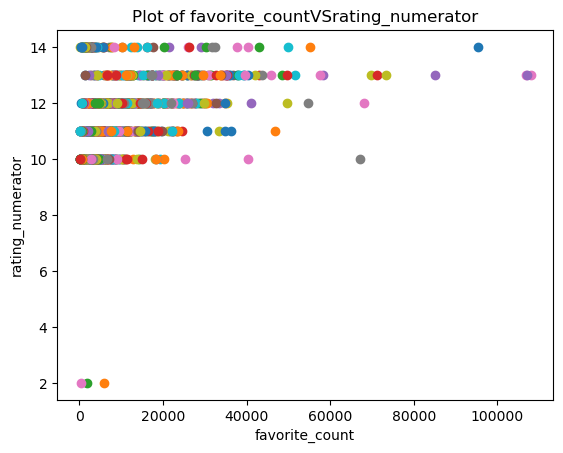

```python
scatter_plots(df, "favorite_count", "rating_numerator");
```

#### **1.** There is a strong correlation between retweet counts and favourite counts but that doest necessarily mean that the most liked dog had the most retweets and likewise.

```python
max_rate = df['favorite_count'].max()
name_col = df.loc[df['favorite_count'] == max_rate, 'name']
name_col
```

```
46    Duddles
Name: name, dtype: object
```

```python
# getting the maximum favorite_count
max_fav = (df[df.favorite_count == df.favorite_count.max()])

list(max_fav.name)
```

```
['Duddles']
```

```python
rate_max = (df[df.rating_numerator == df.rating_numerator.max()])

list(rate_max.name)
```

```
['Cassie',
 'Emmy',
 'Clifford',
 'Walter',
 'Cermet',
 'General',
 'Iggy',
 'Jerry',
 'Smiley',
 'Kuyu',
 'Doobert',
 'Gabe',
 'Sundance',
 'Sunny',
 'Bo',
 'Gary',
 'Sam',
 'Ollie',
 'Laika',
 'Wesley',
 'Toby',
 'Percy',
 'Harold',
 'Kyle',
 'Charles',
 'Alexanderson',
 'Steven',
 'Chester',
 'Jiminus',
 'Elliot',
 'Dexter',
 'Chesterson',
 'Chip',
 'Daniel',
 'Murphy',
 'Eazy',
 'Charl',
 'Rusty',
 'Berb',
 'Brian',
```

[output cut: 23 more lines]

```
 'Ridley',
 'Gizmo',
 'Phred',
 'Jett',
 'Antony',
 'Traviss',
 'Danny',
 'Tommy',
 'Keith',
 'Billl',
 'Bernie',
 'Alfie',
 'Reese',
 'Biden',
 'Clybe']
```

```python
(df[df.rating_numerator == df.rating_numerator.max()])
```

|  | tweet_id | date | time | in_reply_to_status_id | source | text | retweeted_status_user_id | expanded_urls | rating_numerator | rating_denominator | ... | p1_conf | p1_dog | p2 | p2_conf | p2_dog | p3 | p3_conf | p3_dog | favorite_count | retweet_count |
| --- | --- | --- | --- | --- | --- | --- | --- | --- | --- | --- | --- | --- | --- | --- | --- | --- | --- | --- | --- | --- | --- |
| 7 | 890240255349198849 | 2017-07-26 | 15:59:51 | NaN | <a href="http://twitter.com/download/iphone" r... | This is Cassie. She is a college pup. Studying... | NaN | https://twitter.com/dog_rates/status/890240255... | 14 | 10 | ... | 0.511319 | True | Cardigan | 0.451038 | True | Chihuahua | 0.029248 | True | 32467 | 7711 |
| 52 | 878057613040115712 | 2017-06-23 | 01:10:23 | NaN | <a href="http://twitter.com/download/iphone" r... | This is Emmy. She was adopted today. Massive r... | NaN | https://twitter.com/dog_rates/status/878057613... | 14 | 10 | ... | 0.839097 | True | Boston_bull | 0.078799 | True | toy_terrier | 0.015243 | True | 42876 | 7181 |
| 76 | 870063196459192321 | 2017-05-31 | 23:43:25 | NaN | <a href="http://twitter.com/download/iphone" r... | Meet Clifford. He's quite large. Also red. Goo... | NaN | https://twitter.com/dog_rates/status/870063196... | 14 | 10 | ... | 0.534409 | False | envelope | 0.280722 | False | book_jacket | 0.043785 | False | 37771 | 8840 |
| 81 | 868880397819494401 | 2017-05-28 | 17:23:24 | NaN | <a href="http://twitter.com/download/iphone" r... | This is Walter. He won't start hydrotherapy wi... | NaN | https://twitter.com/dog_rates/status/868880397... | 14 | 10 | ... | 0.153718 | False | French_bulldog | 0.099984 | True | printer | 0.077130 | False | 55098 | 12518 |
| 114 | 856282028240666624 | 2017-04-23 | 23:01:59 | NaN | <a href="http://twitter.com/download/iphone" r... | This is Cermet, Paesh, and Morple. They are ab... | NaN | https://twitter.com/dog_rates/status/856282028... | 14 | 10 | ... | 0.876543 | True | Italian_greyhound | 0.032962 | True | Cardigan | 0.020776 | True | 29086 | 6841 |
| ... | ... | ... | ... | ... | ... | ... | ... | ... | ... | ... | ... | ... | ... | ... | ... | ... | ... | ... | ... | ... | ... |
| 1273 | 668989615043424256 | 2015-11-24 | 03:08:48 | NaN | <a href="http://twitter.com/download/iphone" r... | This is Bernie. He's taking his Halloween cost... | NaN | https://twitter.com/dog_rates/status/668989615... | 14 | 10 | ... | 0.917326 | True | waffle_iron | 0.014918 | False | Chihuahua | 0.013524 | True | 726 | 356 |
| 1305 | 668113020489474048 | 2015-11-21 | 17:05:31 | NaN | <a href="http://twitter.com/download/iphone" r... | This is Alfie. He's that one hypocritical gym ... | NaN | https://twitter.com/dog_rates/status/668113020... | 14 | 10 | ... | 0.548896 | True | Cardigan | 0.191101 | True | collie | 0.059814 | True | 709 | 265 |
| 1323 | 667455448082227200 | 2015-11-19 | 21:32:34 | NaN | <a href="http://twitter.com" rel="nofollow">Tw... | This is Reese and Twips. Reese protects Twips.... | NaN | https://twitter.com/dog_rates/status/667455448... | 14 | 10 | ... | 0.676376 | True | Irish_terrier | 0.054933 | True | Yorkshire_terrier | 0.040576 | True | 203 | 66 |
| 1325 | 667405339315146752 | 2015-11-19 | 18:13:27 | NaN | <a href="http://twitter.com/download/iphone" r... | This is Biden. Biden just tripped... 7/10 http... | NaN | https://twitter.com/dog_rates/status/667405339... | 14 | 10 | ... | 0.381377 | True | Leonberg | 0.127998 | True | golden_retriever | 0.069357 | True | 489 | 234 |
| 1336 | 667090893657276420 | 2015-11-18 | 21:23:57 | NaN | <a href="http://twitter.com/download/iphone" r... | This is Clybe. He is an Anemone Valdez. One ea... | NaN | https://twitter.com/dog_rates/status/667090893... | 14 | 10 | ... | 0.959514 | True | Italian_greyhound | 0.005370 | True | Pomeranian | 0.002641 | True | 349 | 132 |

78 rows × 25 columns

```python
# get the first 10 max values in retweet_count column
top_10 = df['rating_numerator'].nlargest(10)

# use the index of the top 10 values to get the corresponding values in col1
top_10_p1 = df.loc[top_10.index, 'p1']

top_10_p1
```

```
7                Pembroke
52         French_bulldog
76             comic_book
81                 laptop
114             Chihuahua
124                prison
126              web_site
135    Bedlington_terrier
199              Pembroke
202            bloodhound
Name: p1, dtype: object
```

```python
# get the first 10 max values in favorite_count column
top_10 = df['rating_numerator'].nsmallest(10)

# use the index of the top 10 values to get the corresponding values in col1
top_10_p1 = df.loc[top_10.index, 'name']

top_10_p1
```

```
1036    Crystal
1102      Henry
1311    Tedrick
136     Georgie
217       Fiona
299     Swagger
305       Augie
371       Maude
393      Stella
402     Lincoln
Name: name, dtype: object
```

```python
# get the first 10 max values in favorite_count column
top_10 = df['rating_numerator'].nsmallest(10)

# use the index of the top 10 values to get the corresponding values in col1
top_10_p1 = df.loc[top_10.index, 'jpg_url']

top_10_p1
```

```
1036    https://pbs.twimg.com/media/CWo_T8gW4AAgJNo.jpg
1102    https://pbs.twimg.com/media/CVt49k_WsAAtNYC.jpg
1311    https://pbs.twimg.com/media/CUTILFiWcAE8Rle.jpg
136     https://pbs.twimg.com/media/C8SRpHNUIAARB3j.jpg
217     https://pbs.twimg.com/media/C4AqLSgVYAEg8nt.jpg
299     https://pbs.twimg.com/media/C0eUHfWUAAANEYr.jpg
305     https://pbs.twimg.com/media/C0N6opSXAAAkCtN.jpg
371     https://pbs.twimg.com/media/CwINKJeW8AYHVkn.jpg
393     https://pbs.twimg.com/media/CvQLdotWcAAZn86.jpg
402     https://pbs.twimg.com/media/Cu0hlfwWYAEdnXO.jpg
Name: jpg_url, dtype: object
```

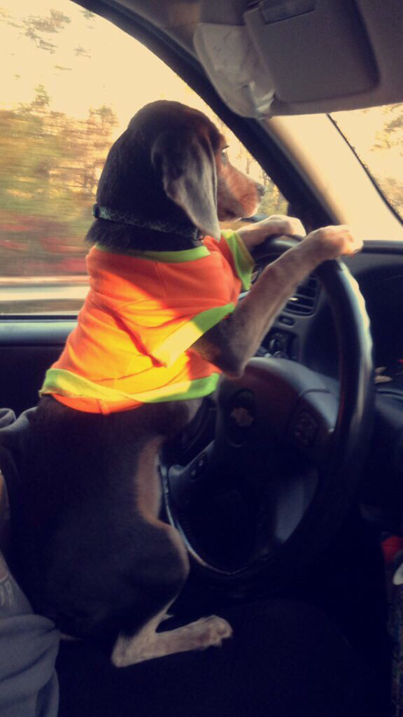

```python
from PIL import Image
import io
import requests

img_link = 'https://pbs.twimg.com/media/CUTILFiWcAE8Rle.jpg'
response = requests.get(img_link)
img = Image.open(io.BytesIO(response.content));



display(img)
```

```python
img.save("image.png")
```